# Pre-Analysis F1 Data

The purpose of this notebook is to clean the F1 data so I can work with it for my analysis of winning teams.

Let’s first load the right libraries:

```r
library(tidyverse)
```

And our data:

```r
race_results <- read_csv("../data/race_results_statsf1.csv")
head(race_results)
```

| race_id | year | round | race_name | position | p_prelim | driver | team | constructor_long | extra |
| --- | --- | --- | --- | --- | --- | --- | --- | --- | --- |
| 1 | 1950 | 1 | Britain | 1 | 1 | Giuseppe FARINA | Alfa Romeo | Alfa Romeo-Alfa Romeo | 2h 13m 23.6s ( 146.378 km/h ) |
| 1 | 1950 | 1 | Britain | 2 | 2 | Luigi FAGIOLI | Alfa Romeo | Alfa Romeo-Alfa Romeo | 2h 13m 26.2s ( +02.6s ) |
| 1 | 1950 | 1 | Britain | 3 | 3 | Reg PARNELL | Alfa Romeo | Alfa Romeo-Alfa Romeo | 2h 14m 15.6s ( +52.0s ) |
| 1 | 1950 | 1 | Britain | 4 | 4 | Yves GIRAUD-CABANTOUS | Talbot Lago | Talbot Lago-Talbot |  |
| 1 | 1950 | 1 | Britain | 5 | 5 | Louis ROSIER | Talbot Lago | Talbot Lago-Talbot |  |
| 1 | 1950 | 1 | Britain | 6 | 6 | Bob GERARD | ERA | ERA-ERA |  |

## Looking at the data before we clean

With this dataset, we have the following columns:

## Explore & Verify variables

Let’s go variable by variable, see what’s there and then try to make notes of how we might clean this.

### `race_id`

Let’s look at just this variable right now:

```r
summary(race_results["race_id"])
```

```
    race_id
 Min.   :   1.0
 1st Qu.: 248.0
 Median : 474.0
 Mean   : 488.2
 3rd Qu.: 732.0
 Max.   :1035.0
```

So that looks good.

### `year`

```r
summary(race_results["year"])
```

```
      year
 Min.   :1950
 1st Qu.:1974
 Median :1989
 Mean   :1988
 3rd Qu.:2005
 Max.   :2020
```

### `round`

This corresponds to the order of the race in each season. We could check it by seeing how many races there were each year.

```r
race_results %>%
  select(year, round) %>%
  distinct(year, round) %>%
  group_by(year) %>%
  summarise(races_count = n())
```

| year | races_count |
| --- | --- |
| 1950 | 7 |
| 1951 | 8 |
| 1952 | 8 |
| 1953 | 9 |
| 1954 | 9 |
| 1955 | 7 |
| 1956 | 8 |
| 1957 | 8 |
| 1958 | 11 |
| 1959 | 9 |

[output cut: 61 more lines]

Let’s try to visualize that, by first saving all that previous code to a variable:

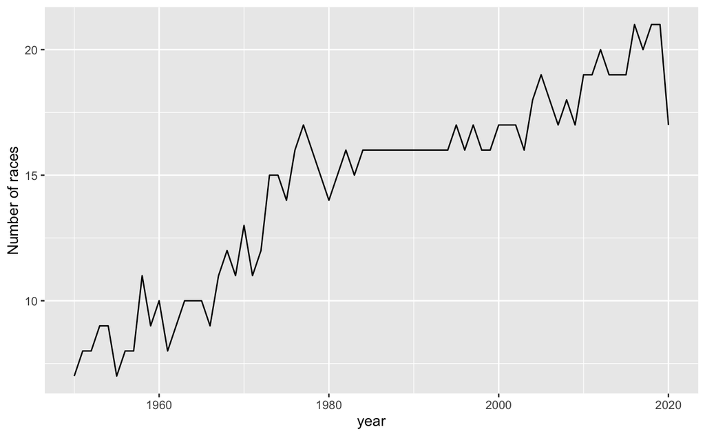

```r
annual_races_count <- race_results %>%
                      select(year, round) %>%
                      distinct(year, round) %>%
                      group_by(year) %>%
                      summarise(races_count = n())

ggplot(annual_races_count, aes(x=year, y=races_count))+
         geom_line() + labs(y="Number of races")
```

The first season had 7 races and over time, we got more races. It’d be interesting to explore **why** the number of races went up. (It’s a result of marketing and sponsorship, but it’d be cool to see what the changes meant.)

### `race_name`

`race_name` refers to the country where races were held. Let’s explore this variable to see what country has hosted the most races:

```r
race_results %>% select(race_name) %>%
  group_by(race_name) %>% summarize(count = n())
```

| race_name | count |
| --- | --- |
| 70th Anniversary | 20 |
| Abu Dhabi | 256 |
| Argentina | 462 |
| Australia | 839 |
| Austria | 834 |
| Azerbaijan | 60 |
| Bahrain | 341 |
| Belgium | 1584 |
| Brazil | 1159 |
| Britain | 1860 |

[output cut: 37 more lines]

Looking at just the race names is difficult. So let’s look at the race_name and year.

```r
race_results %>% select(year, race_name) %>%
                  distinct(year, race_name) %>%
                  group_by(race_name) %>%
                  summarize(count = n()) %>%
                  arrange(desc(count))
```

| race_name | count |
| --- | --- |
| Britain | 71 |
| Italy | 71 |
| Monaco | 66 |
| Belgium | 65 |
| Germany | 64 |
| France | 60 |
| Canada | 50 |
| Spain | 50 |
| Brazil | 47 |
| USA | 41 |

[output cut: 37 more lines]

Italy and Britain have hosted the most races. If we look at the data though there’s some weirdness like there being USA, USA East, USA West, Indianapolis, and Las Vegas as all being Grand Prixs that happened in America. For my analysis where I’m looking at team performance, I don’t mind this issue as much, but good to note it now.

If I cared about this variable, I might make a new variable for country and create the values for that variable based on this variable.

### `position`

The driver’s finishing position. It’s either a number or a alphanumeric code with definitions [here](https://www.statsf1.com/en/saisons.aspx). Just in case let’s try to explain them:

- ab: Retired
- nc : Not classified
- np : Not started
- nq : Not qualified
- npq : Not pre-qualified
- dsq : Disqualified
- exc : Excluded
- f : Withdrawal
- tf : Parade lap

To really understand these, I’d read up on races where these symbols showed up. I’ll save that for a later day

**TODO**: Find out the best explanation of what each of the above codes mean with examples.

### `p_prelim`

My interpretation of the position column. I need to verify this thoroughly to explain the logic I took when I scraped. But I might just create a new column based on the position column.

```r
summary(race_results["p_prelim"])
```

```
    p_prelim
 Min.   :-1.00
 1st Qu.: 7.00
 Median :13.00
 Mean   :13.58
 3rd Qu.:19.00
 Max.   :77.00
```

`-1` here means the driver was disqualified.

**TODO**: Figure out what the logic for this part was and try to make sure it’s correct.

**TODO**: Rename column

### `driver`

The driver’s name. Most of them got scraped well but not all. Would be a good idea to clean the messed up one. We can check which ones need cleaning by seeing how many times each driver competed in F1.

```r
race_results %>% select(race_id, driver) %>%
                  distinct(race_id, driver) %>%
                  group_by(driver) %>%
                  summarize(count = n()) %>%
                  arrange(desc(count))
```

| driver | count |
| --- | --- |
| Kimi RAIKKONEN | 332 |
| Rubens BARRICHELLO | 326 |
| Fernando ALONSO | 315 |
| Jenson BUTTON | 311 |
| Michael SCHUMACHER | 308 |
| Felipe MASSA | 272 |
| Lewis HAMILTON | 266 |
| Riccardo PATRESE | 258 |
| Sebastian VETTEL | 258 |
| Jarno TRULLI | 256 |

[output cut: 969 more lines]

Looking at the list, the names that need to be fixed are: * `Andr� GUELFI` to `André GUELFI`  
* `Andr� LOTTERER` to `André LOTTERER`  
* `Andr� MILHOUX` to `André MILHOUX`  
* `Andr� PILETTE` to `André PILETTE`  
* `Andr� SIMON` to `André SIMON`  
* `Andr� TESTUT` to `André TESTUT`  
* `Azdr�bal BAYARDO` to `Azdrúbal BAYARDO`  
* `Eug�ne CHABOUD` to `Eugène CHABOUD`  
* `Eug�ne MARTIN` to `Eugène MARTIN`  
* `Fran�ois CEVERT` to `François CEVERT`  
* `Fran�ois HESNAULT` to `François HESNAULT`  
* `Fran�ois MAZET` to `François MAZET`  
* `Fran�ois MIGAULT` to `François MIGAULT`  
* `G�nther BECHEM` to `Günther BECHEM`  
* `G�rard LARROUSSE` to `Gérard LARROUSSE`  
* `Jean-�ric VERGNE` to `Jean-Éric VERGNE`  
* `Jos� DOLHEM` to `José DOLHEM`  
* `J�r�me d'AMBROSIO` to `Jérôme d'AMBROSIO`  
* `Peter ST�CHELIN` to `Peter STÆCHELIN`  
* `Ren� ARNOUX` to `René ARNOUX`  
* `S�bastien BOURDAIS` to `Sébastien BOURDAIS`  
* `St�phane SARRAZIN` to `Stéphane SARRAZIN`  
* `S�bastien BUEMI` to `Sébastien BUEMI`  
* `Tom BELS�` to `Tom BELSØ`

**TODO**: Fix driver names

### `team`

The name of the team the driver was driving for. The team is the one producing the car so they’re also called constructor.

**TODO:** Rename column to constructor.

Let’s look at what teams have been around:

```r
race_results %>% select(race_id, team)%>%
                  distinct(race_id, team) %>%
                  group_by(team) %>%
                  summarize(count = n())
```

| team | count |
| --- | --- |
| A-T-S | 10 |
| Adams | 2 |
| AFM | 4 |
| AGS | 81 |
| Alfa Romeo | 149 |
| Alfa Special | 2 |
| AlphaTauri | 17 |
| Alta | 5 |
| Amon | 5 |
| Andrea Moda | 12 |

[output cut: 207 more lines]

**TODO**: Figure out what those `*` next to some teams mean. How should we deal with those? Some examples we have are `Brabham *`, `Cooper *`, `Ferrari *`, `Lola *`, `Lotus *`, `Matra *`, `Porsche *`,`Protos *`, `Tecno *`, `Tojeiro *`.

**TODO**: Fix team names like `Ekstr�m`

There were some `NA` for rows that had `position == '&'`. We should fill with the value from above

**TODO**: Fill the team values that were `NA`.

### `constructor_long`

The combination of constructor and engine. Let’s look at them:

```r
select(race_results, race_id, constructor_long)%>%
  distinct(race_id, constructor_long) %>%
  group_by(constructor_long) %>%
  summarize(count = n())
```

| constructor_long | count |
| --- | --- |
| - | 47 |
| A-T-S-A-T-S | 10 |
| Adams-Offenhauser | 2 |
| AFM-BMW | 2 |
| AFM-Bristol | 2 |
| AFM-Küchen | 1 |
| AGS-Ford Cosworth | 79 |
| AGS-Motori Moderni | 2 |
| Alfa Romeo-Alfa Romeo | 111 |
| Alfa Romeo-Ferrari | 38 |

[output cut: 383 more lines]

I don’t particularly care about this column, so there is no real need to clean it at the moment.

### `extra`

This column contains a variety of extra information like finishing times, lap times, and reasons for not finishing a race among other things. This column should definitely be cleaned up of the extra broken characters, because it might be good to look at the common reasons for not finishing a race. We would definitely have to find a way of getting rid of the lap times and such.

**TODO**: Clear random characters.

## Cleaning Data

While verifying the variables, I’ve left a list of **TODO**s to look at. Let’s try to address the following in cleaning.

1. For `position`:
   - Find out the best explanation of what each of the above codes mean with examples.
2. For `p_prelim`:
   - Rename the column to be something like `position_numeric`.
   - Figure out what the logic for this part was and try to make sure it’s correct.
3. For `driver`:
   - Fix names
4. For `team`:
   - Rename column to `constructor`.
   - Figure out what those `*` next to some teams mean. How should we deal with those? Some examples we have are `Brabham *`, `Cooper *`, `Ferrari *`, `Lola *`, `Lotus *`, `Matra *`, `Porsche *`,`Protos *`, `Tecno *`, `Tojeiro *`.
   - Fix team names like `Ekstr�m`
   - Fill the team values that were `NA`.
5. For `extra`:
   - Remove random character.

### Updating `p_prelim`

#### Scraping logic

`p_prelim` is an interpretation of `position` to have all the drivers listed in numerical order. The script I used to get this data is in my `scripts` folder at: `/scripts/get_race_results_statsf1.py`.

Initially, I worked with this logic:

```
if position == "&":
    # driver finish tied to previous row
    p = p_index - 1
elif position == "dsq":
    # driver disqualified
    p = -1
else:
    p = max(p_index, p_index-1)
    p_index += 1
```

As the script ran, it would go result by result. The first result would get `p_index` of `1`. `p_index` was a variable that was saved as `p_prelim`. The next result would be `p_index` of `2`. This worked great for numeric. If the position was `&` the result referred to a shared drive so the driver should have the same `p_index` as the previous result. For disqualified drivers, I set `p_index` to `-1`. That seemed to work for most of my data.

#### Logic I previously used.

This seemed to work to a degree, but I wanted something to work a little better. Looking at the results previously (check `attempt04` in my archive which has the analysis for the 1950 through 2018 seasons that I used in my first draft of capstone work.)

We can write little code chunks to address each of these points.

### Creating `position_numeric`

```r
ptm <- proc.time()

get_last <- function(some_race_id) {
  last <- race_results %>%
    select(race_id, position, driver) %>%
    filter(race_id == some_race_id) %>%
    distinct(race_id,driver) %>%
    summarise(count=n()) %>%
    pull(count)
  return(last)
}

race_results_cleaning <- race_results %>%
  rowwise() %>%
  mutate(position_numeric_a =
           case_when(position == "np" |
                       position == "f" ~
                       get_last(race_id)))
```

Let’s update the disqualified drivers, where `position == "dsq"`. This should be the last place plus 1.

Later we can update the column to be numeric. So this is a good test.

Let’s keep interpreting the position columns and later combining them. Next we’ll do the position values we’re setting to zero: `npq`, `nq`, `tf`,and `ex`.

And for some of the other position values we can just pass the p_prelim value forward.

Now we can move to combining all those different `position_numeric_*` into one.

Before we move on, let’s turn the `position_numeric` into a double. We can also get rid of `p_prelim` since we have interpreted the `position`.

Next up, let’s move to fixing the names.

### Fixing `driver` names

There are a lot of names that loaded funny because of some encoding issue. Let’s try to rename them and save to make sure that the names are fixed.

Previously I had listed all the names that had to change. They can be more quickly summarized as: * `Andr�` to `André` * `Azdr�bal` to `Azdrúbal` * `Eug�ne` to `Eugène`  
* `Fran�ois` to `François` * `G�nther` to `Günther`  
* `G�rard` to `Gérard`  
* `Jean-�ric` to `Jean-Éric`  
* `Jos�` to `José`  
* `J�r�me` to `Jérôme`  
* `ST�CHELIN` to `STÆCHELIN`  
* `Ren�` to `René`  
* `S�bastien` to `Sébastien`  
* `St�phane` to `Stéphane`  
* `BELS�` to `BELSØ`

### Looking at `team`

Looking at this column: * I want to go and clean it up a little bit. I want to rename the column from `team` to `constructor` because that’s the term used in F1. I also want to figure out what the `*` in some constructor names were. * I want to investigate the teams that have an `*` in their name. * I want to fill in the `team` and `constructor_long` for the rows with shared drives.

#### Filling in `team` and `constructor_long`

We can first replace the missing teams with `fill()`.

#### `*` in the name

I picked a particular race where teams with `*` showed up, the 1958 German Grand Prix. Looking at the [results on Stats F1](https://www.statsf1.com/en/1958/allemagne/classement.aspx), the `*` is a note that those drivers were racing Formula Two cars in Formula One. For some analysis, this distinction might be important so we could proceed with two different ways:

1. Remove the `*` if we don’t care that the cars were F2 cars.
2. Remove those rows, if we care that the cars were F2 cars.

I particularly don’t care too much that the cars were F2 so I’ll remove the asterisk. But before that I’ll add a column to mark whether the car is F1 or F2, in case I want to look at that distinction later.

Let’s add that column to our main data:

And now we can remove the `*` from both the team and `constructor_long` columns:

Let’s also fix the team `Ekstr�m`

And finally we can rename the team column to `constructor`

### Looking at racing location

Let’s make that column for race countries… because, why not. Looking at all the race_names, they are mostly good except some odd cases. * European was held in various countries based on year [Wikipedia](https://en.wikipedia.org/wiki/European_Grand_Prix#As_an_honorific_title) * There have been 5 different grand prixs in America. * Pacific GP was in Japan * Abu Dhabi GP is in UAE * Both Pescara and San Marino GP are in Italy